# Class-Survival Gap: Mediation Analysis via Access and Constraints

Author

CLI Copilot

## Executive Summary

This analysis investigates the research question: **To what extent is the survival advantage of 1st class passengers mediated by location/access (deck/cabin proximity, boarding points) versus policy (“women and children first”)?** We approach this as a mediation question where we decompose the total effect of passenger class on survival into direct effects and effects mediated through access-related mechanisms.

## 1. Research Context and Conceptual Framework

### 1.1 The Research Question

The survival advantage enjoyed by 1st class passengers during the Titanic disaster is well-documented. However, understanding *why* this advantage existed requires us to examine potential mechanisms. We hypothesize that class advantages operate through two pathways:

1. **Access/Constraints pathway**: 1st class passengers may have had better physical access to lifeboats, proximity to key locations, and earlier knowledge of the disaster.
2. **Policy pathway**: The “women and children first” policy may have been more effectively enforced or applied in 1st class areas.

### 1.2 Why This Matters

Rather than treating class as a monolithic predictor, decomposing its effects reveals the structural mechanisms underlying survival disparities. This distinction has important implications for understanding historical disasters and modern safety protocols.

### 1.3 Operationalization Strategy

We will use the following approach to operationalize this mediation analysis:

- **Total Effect**: The overall association between passenger class and survival
- **Mediation Proxies (Access/Constraints)**:
  - **Cabin information**: Presence/absence and cabin letter (as proxy for deck location)
  - **Fare**: As a proxy for accommodation quality and deck location
  - **Embarked port**: As proxy for boarding point and embarkation procedures
  - **Ticket family size** (SibSp + Parch): Constraint on movement and access to lifeboats
- **Direct Effect**: The class effect after accounting for access mediators

## 2. Data Preparation and Exploratory Analysis

```r
library(tidyverse)
library(knitr)
library(ggplot2)

# Read the training data
train <- read.csv("../../data/train.csv")

# Display basic structure
head(train)
```

```
  PassengerId Survived Pclass
1           1        0      3
2           2        1      1
3           3        1      3
4           4        1      1
5           5        0      3
6           6        0      3
                                                 Name    Sex Age SibSp Parch
1                             Braund, Mr. Owen Harris   male  22     1     0
2 Cumings, Mrs. John Bradley (Florence Briggs Thayer) female  38     1     0
3                              Heikkinen, Miss. Laina female  26     0     0
4        Futrelle, Mrs. Jacques Heath (Lily May Peel) female  35     1     0
5                            Allen, Mr. William Henry   male  35     0     0
6                                    Moran, Mr. James   male  NA     0     0
            Ticket    Fare Cabin Embarked
1        A/5 21171  7.2500              S
2         PC 17599 71.2833   C85        C
3 STON/O2. 3101282  7.9250              S
4           113803 53.1000  C123        S
5           373450  8.0500              S
6           330877  8.4583              Q
```

```r
str(train)
```

```
'data.frame':   891 obs. of  12 variables:
 $ PassengerId: int  1 2 3 4 5 6 7 8 9 10 ...
 $ Survived   : int  0 1 1 1 0 0 0 0 1 1 ...
 $ Pclass     : int  3 1 3 1 3 3 1 3 3 2 ...
 $ Name       : chr  "Braund, Mr. Owen Harris" "Cumings, Mrs. John Bradley (Florence Briggs Thayer)" "Heikkinen, Miss. Laina" "Futrelle, Mrs. Jacques Heath (Lily May Peel)" ...
 $ Sex        : chr  "male" "female" "female" "female" ...
 $ Age        : num  22 38 26 35 35 NA 54 2 27 14 ...
 $ SibSp      : int  1 1 0 1 0 0 0 3 0 1 ...
 $ Parch      : int  0 0 0 0 0 0 0 1 2 0 ...
 $ Ticket     : chr  "A/5 21171" "PC 17599" "STON/O2. 3101282" "113803" ...
 $ Fare       : num  7.25 71.28 7.92 53.1 8.05 ...
 $ Cabin      : chr  "" "C85" "" "C123" ...
 $ Embarked   : chr  "S" "C" "S" "S" ...
```

We begin by loading the Titanic training dataset and examining its structure. This step is essential to understand what variables we have available and their basic characteristics. The training data contains 891 passengers with 12 variables including demographics (Age, Sex), socioeconomic status (Pclass, Fare), family structure (SibSp, Parch), cabin information, and our outcome variable (Survived).

```r
# Create summary statistics
summary_stats <- train %>%
  summarise(
    n_passengers = n(),
    n_survived = sum(Survived == 1),
    survival_rate = round(mean(Survived), 4),
    n_missing_cabin = sum(is.na(Cabin)),
    n_missing_age = sum(is.na(Age)),
    n_missing_embarked = sum(is.na(Embarked))
  )

kable(summary_stats, caption = "Dataset Overview")
```

Dataset Overview

| n_passengers | n_survived | survival_rate | n_missing_cabin | n_missing_age | n_missing_embarked |
| --- | --- | --- | --- | --- | --- |
| 891 | 342 | 0.3838 | 0 | 177 | 0 |

```r
survival_by_class <- train %>%
  group_by(Pclass) %>%
  summarise(
    n = n(),
    n_survived = sum(Survived == 1),
    survival_rate = round(mean(Survived), 4),
    .groups = 'drop'
  )

kable(survival_by_class, caption = "Survival Rates by Passenger Class")
```

Survival Rates by Passenger Class

| Pclass | n | n_survived | survival_rate |
| --- | --- | --- | --- |
| 1 | 216 | 136 | 0.6296 |
| 2 | 184 | 87 | 0.4728 |
| 3 | 491 | 119 | 0.2424 |

This exploratory analysis quantifies the raw survival disparities across passenger classes. We observe substantial differences in survival rates that form the “total effect” we aim to decompose. The table shows both the absolute number of survivors and the proportion, providing context for the magnitude of the class effect.

### 2.1 Missing Data Analysis

```r
# Examine missing data patterns
missing_by_class <- train %>%
  group_by(Pclass) %>%
  summarise(
    pct_missing_cabin = round(100 * sum(is.na(Cabin)) / n(), 1),
    pct_missing_age = round(100 * sum(is.na(Age)) / n(), 1),
    pct_missing_embarked = round(100 * sum(is.na(Embarked)) / n(), 1),
    .groups = 'drop'
  ) %>%
  mutate(Pclass = paste0("Class ", Pclass))

kable(missing_by_class, caption = "Percentage of Missing Values by Class")
```

Percentage of Missing Values by Class

| Pclass | pct_missing_cabin | pct_missing_age | pct_missing_embarked |
| --- | --- | --- | --- |
| Class 1 | 0 | 13.9 | 0 |
| Class 2 | 0 | 6.0 | 0 |
| Class 3 | 0 | 27.7 | 0 |

## 3. Mediation Proxy Construction

### 3.1 Cabin-Based Access Proxy

```r
# Extract cabin letter as proxy for deck location
train <- train %>%
  mutate(
    cabin_known = !is.na(Cabin),
    cabin_letter = ifelse(!is.na(Cabin),
                          substr(Cabin, 1, 1),
                          NA),
    cabin_letter = factor(cabin_letter)
  )

# Summary of cabin information by class
cabin_summary <- train %>%
  group_by(Pclass) %>%
  summarise(
    pct_cabin_known = round(100 * mean(cabin_known), 1),
    n_distinct_cabins = n_distinct(Cabin, na.rm = TRUE),
    .groups = 'drop'
  ) %>%
  mutate(Pclass = paste0("Class ", Pclass))

kable(cabin_summary, caption = "Cabin Information by Class")
```

Cabin Information by Class

| Pclass | pct_cabin_known | n_distinct_cabins |
| --- | --- | --- |
| Class 1 | 100 | 134 |
| Class 2 | 100 | 8 |
| Class 3 | 100 | 8 |

```r
# Cabin letter distribution among those with known cabin
cabin_letter_dist <- train %>%
  filter(!is.na(cabin_letter)) %>%
  group_by(Pclass, cabin_letter) %>%
  summarise(
    count = n(),
    survival_rate = round(mean(Survived), 3),
    .groups = 'drop'
  ) %>%
  arrange(Pclass, cabin_letter)

kable(cabin_letter_dist, caption = "Cabin Letter Distribution and Survival Rates (Among Passengers with Known Cabin)")
```

Cabin Letter Distribution and Survival Rates (Among Passengers with Known Cabin)

| Pclass | cabin_letter | count | survival_rate |
| --- | --- | --- | --- |
| 1 |  | 40 | 0.475 |
| 1 | A | 15 | 0.467 |
| 1 | B | 47 | 0.745 |
| 1 | C | 59 | 0.593 |
| 1 | D | 29 | 0.759 |
| 1 | E | 25 | 0.720 |
| 1 | T | 1 | 0.000 |
| 2 |  | 168 | 0.440 |
| 2 | D | 4 | 0.750 |
| 2 | E | 4 | 0.750 |
| 2 | F | 8 | 0.875 |
| 3 |  | 479 | 0.236 |
| 3 | E | 3 | 1.000 |
| 3 | F | 5 | 0.200 |
| 3 | G | 4 | 0.500 |

### 3.2 Fare as Proxy for Accommodation Quality and Location

```r
# Analyze fare by class and survival
fare_analysis <- train %>%
  filter(!is.na(Fare)) %>%
  group_by(Pclass, Survived) %>%
  summarise(
    mean_fare = round(mean(Fare), 2),
    median_fare = round(median(Fare), 2),
    n = n(),
    .groups = 'drop'
  )

kable(fare_analysis, caption = "Fare Distribution by Class and Survival Status")
```

Fare Distribution by Class and Survival Status

| Pclass | Survived | mean_fare | median_fare | n |
| --- | --- | --- | --- | --- |
| 1 | 0 | 64.68 | 44.75 | 80 |
| 1 | 1 | 95.61 | 77.96 | 136 |
| 2 | 0 | 19.41 | 13.00 | 97 |
| 2 | 1 | 22.06 | 21.00 | 87 |
| 3 | 0 | 13.67 | 8.05 | 372 |
| 3 | 1 | 13.69 | 8.52 | 119 |

```r
# Examine fare variation within classes
fare_by_class_sex <- train %>%
  filter(!is.na(Fare)) %>%
  group_by(Pclass, Sex) %>%
  summarise(
    mean_fare = round(mean(Fare), 2),
    sd_fare = round(sd(Fare), 2),
    n = n(),
    .groups = 'drop'
  )

kable(fare_by_class_sex, caption = "Mean Fare by Class and Sex")
```

Mean Fare by Class and Sex

| Pclass | Sex | mean_fare | sd_fare | n |
| --- | --- | --- | --- | --- |
| 1 | female | 106.13 | 74.26 | 94 |
| 1 | male | 67.23 | 77.55 | 122 |
| 2 | female | 21.97 | 10.89 | 76 |
| 2 | male | 19.74 | 14.92 | 108 |
| 3 | female | 16.12 | 11.69 | 144 |
| 3 | male | 12.66 | 11.68 | 347 |

Fare represents a continuous measure of accommodation quality and likely correlates with cabin location on the ship. Higher fares typically purchased cabins in more desirable, higher-decked locations with faster access to lifeboats. We examine fare distributions to understand whether class differences in survival persist after accounting for the economic/locational advantages captured by fare.

### 3.3 Embarked Port as Access Proxy

```r
# Port of embarkation analysis
embarked_summary <- train %>%
  filter(!is.na(Embarked)) %>%
  group_by(Pclass, Embarked) %>%
  summarise(
    n = n(),
    survival_rate = round(mean(Survived), 3),
    .groups = 'drop'
  ) %>%
  arrange(Pclass, Embarked)

kable(embarked_summary, caption = "Embarkation Port Distribution by Class")
```

Embarkation Port Distribution by Class

| Pclass | Embarked | n | survival_rate |
| --- | --- | --- | --- |
| 1 |  | 2 | 1.000 |
| 1 | C | 85 | 0.694 |
| 1 | Q | 2 | 0.500 |
| 1 | S | 127 | 0.583 |
| 2 | C | 17 | 0.529 |
| 2 | Q | 3 | 0.667 |
| 2 | S | 164 | 0.463 |
| 3 | C | 66 | 0.379 |
| 3 | Q | 72 | 0.375 |
| 3 | S | 353 | 0.190 |

```r
# Survival rate by embarkation port
port_survival <- train %>%
  filter(!is.na(Embarked)) %>%
  group_by(Embarked) %>%
  summarise(
    n = n(),
    survival_rate = round(mean(Survived), 3),
    .groups = 'drop'
  ) %>%
  mutate(
    Embarked = case_when(
      Embarked == "C" ~ "Cherbourg",
      Embarked == "Q" ~ "Queenstown",
      Embarked == "S" ~ "Southampton"
    )
  )

kable(port_survival, caption = "Survival Rate by Embarkation Port")
```

Survival Rate by Embarkation Port

| Embarked | n | survival_rate |
| --- | --- | --- |
| NA | 2 | 1.000 |
| Cherbourg | 168 | 0.554 |
| Queenstown | 77 | 0.390 |
| Southampton | 644 | 0.337 |

The port of embarkation serves as a proxy for boarding procedures and potential early warning/evacuation opportunities. Passengers embarking from different ports may have experienced different embarkation procedures, crowding conditions, and communication about the ship’s itinerary, all of which could influence evacuation outcomes.

### 3.4 Family Size as Constraint Proxy

```r
# Create family size variable
train <- train %>%
  mutate(
    family_size = SibSp + Parch + 1,  # +1 to include the passenger
    is_alone = (family_size == 1),
    is_large_family = (family_size > 4)
  )

# Family size analysis
family_analysis <- train %>%
  group_by(Pclass, is_alone) %>%
  summarise(
    n = n(),
    survival_rate = round(mean(Survived), 3),
    .groups = 'drop'
  ) %>%
  mutate(family_status = ifelse(is_alone, "Traveling Alone", "With Family"))

kable(family_analysis, caption = "Survival Rates: Traveling Alone vs. With Family, by Class")
```

Survival Rates: Traveling Alone vs. With Family, by Class

| Pclass | is_alone | n | survival_rate | family_status |
| --- | --- | --- | --- | --- |
| 1 | FALSE | 107 | 0.729 | With Family |
| 1 | TRUE | 109 | 0.532 | Traveling Alone |
| 2 | FALSE | 80 | 0.637 | With Family |
| 2 | TRUE | 104 | 0.346 | Traveling Alone |
| 3 | FALSE | 167 | 0.299 | With Family |
| 3 | TRUE | 324 | 0.213 | Traveling Alone |

```r
family_size_dist <- train %>%
  group_by(Pclass, family_size) %>%
  summarise(
    n = n(),
    survival_rate = round(mean(Survived), 3),
    .groups = 'drop'
  ) %>%
  arrange(Pclass, family_size)

kable(family_size_dist, caption = "Survival Rates by Family Size and Class")
```

Survival Rates by Family Size and Class

| Pclass | family_size | n | survival_rate |
| --- | --- | --- | --- |
| 1 | 1 | 109 | 0.532 |
| 1 | 2 | 70 | 0.729 |
| 1 | 3 | 24 | 0.750 |
| 1 | 4 | 7 | 0.714 |
| 1 | 5 | 2 | 1.000 |
| 1 | 6 | 4 | 0.500 |
| 2 | 1 | 104 | 0.346 |
| 2 | 2 | 34 | 0.529 |
| 2 | 3 | 31 | 0.677 |
| 2 | 4 | 13 | 0.769 |
| 2 | 5 | 1 | 1.000 |
| 2 | 6 | 1 | 1.000 |
| 3 | 1 | 324 | 0.213 |
| 3 | 2 | 57 | 0.351 |
| 3 | 3 | 47 | 0.426 |
| 3 | 4 | 9 | 0.667 |
| 3 | 5 | 12 | 0.000 |
| 3 | 6 | 17 | 0.000 |
| 3 | 7 | 12 | 0.333 |
| 3 | 8 | 6 | 0.000 |
| 3 | 11 | 7 | 0.000 |

Family size constrains individual evacuation decisions and mobility during the disaster. Passengers traveling with larger families faced coordination challenges and may have prioritized keeping families together over rapid evacuation. This variable serves as a proxy for practical constraints on accessing lifeboats, independent of policy or cabin location.

## 4. Mediation Analysis: Decomposing Class Effects

### 4.1 Model 1: Total Effect of Class on Survival

```r
# Fit model with class only
model1 <- glm(Survived ~ factor(Pclass),
              family = binomial(link = "logit"),
              data = train)

summary(model1)
```

```
Call:
glm(formula = Survived ~ factor(Pclass), family = binomial(link = "logit"),
    data = train)

Coefficients:
                Estimate Std. Error z value Pr(>|z|)
(Intercept)       0.5306     0.1409   3.766 0.000166 ***
factor(Pclass)2  -0.6394     0.2041  -3.133 0.001731 **
factor(Pclass)3  -1.6704     0.1759  -9.496  < 2e-16 ***
---
Signif. codes:  0 '***' 0.001 '**' 0.01 '*' 0.05 '.' 0.1 ' ' 1

(Dispersion parameter for binomial family taken to be 1)

    Null deviance: 1186.7  on 890  degrees of freedom
Residual deviance: 1083.1  on 888  degrees of freedom
AIC: 1089.1

Number of Fisher Scoring iterations: 4
```

```r
# Extract coefficients
model1_coef <- coef(model1)
model1_summary <- data.frame(
  Term = names(model1_coef),
  Coefficient = round(model1_coef, 4),
  OR = round(exp(model1_coef), 4)
)

kable(model1_summary, caption = "Model 1: Total Effect - Class on Survival (Logistic Regression)")
```

Model 1: Total Effect - Class on Survival (Logistic Regression)

|  | Term | Coefficient | OR |
| --- | --- | --- | --- |
| (Intercept) | (Intercept) | 0.5306 | 1.7000 |
| factor(Pclass)2 | factor(Pclass)2 | -0.6394 | 0.5276 |
| factor(Pclass)3 | factor(Pclass)3 | -1.6704 | 0.1882 |

Model 1 establishes the baseline relationship between passenger class and survival. This represents the total effect we aim to decompose. The logistic regression coefficients show how class membership is associated with survival odds, with class 1 as the reference category. These coefficients provide the baseline against which we will compare subsequent models that include potential mediators.

### 4.2 Model 2: Class + Cabin Access Mediators

```r
# Prepare data for Model 2 (exclude rows missing cabin information)
train_cabin_subset <- train %>%
  filter(!is.na(Cabin))

model2 <- glm(Survived ~ factor(Pclass) + cabin_known + factor(cabin_letter),
              family = binomial(link = "logit"),
              data = train_cabin_subset)

summary(model2)
```

```
Call:
glm(formula = Survived ~ factor(Pclass) + cabin_known + factor(cabin_letter),
    family = binomial(link = "logit"), data = train_cabin_subset)

Coefficients: (1 not defined because of singularities)
                       Estimate Std. Error z value Pr(>|z|)
(Intercept)            -0.22016    0.29390  -0.749  0.45380
factor(Pclass)2         0.01106    0.32363   0.034  0.97273
factor(Pclass)3        -0.95574    0.31089  -3.074  0.00211 **
cabin_knownTRUE              NA         NA      NA       NA
factor(cabin_letter)A   0.08663    0.59518   0.146  0.88427
factor(cabin_letter)B   1.29060    0.44529   2.898  0.00375 **
factor(cabin_letter)C   0.59746    0.39575   1.510  0.13112
factor(cabin_letter)D   1.35826    0.48232   2.816  0.00486 **
factor(cabin_letter)E   1.42401    0.46927   3.035  0.00241 **
factor(cabin_letter)F   1.07325    0.59394   1.807  0.07076 .
factor(cabin_letter)G   1.17590    1.00569   1.169  0.24230
factor(cabin_letter)T -13.34590  535.41125  -0.025  0.98011
---
Signif. codes:  0 '***' 0.001 '**' 0.01 '*' 0.05 '.' 0.1 ' ' 1

(Dispersion parameter for binomial family taken to be 1)

    Null deviance: 1186.7  on 890  degrees of freedom
Residual deviance: 1057.3  on 880  degrees of freedom
AIC: 1079.3

Number of Fisher Scoring iterations: 12
```

```r
model2_coef <- coef(model2)
model2_summary <- data.frame(
  Term = names(model2_coef),
  Coefficient = round(model2_coef, 4),
  OR = round(exp(model2_coef), 4)
)

kable(model2_summary, caption = "Model 2: Class + Cabin Location Mediators")
```

Model 2: Class + Cabin Location Mediators

|  | Term | Coefficient | OR |
| --- | --- | --- | --- |
| (Intercept) | (Intercept) | -0.2202 | 0.8024 |
| factor(Pclass)2 | factor(Pclass)2 | 0.0111 | 1.0111 |
| factor(Pclass)3 | factor(Pclass)3 | -0.9557 | 0.3845 |
| cabin_knownTRUE | cabin_knownTRUE | NA | NA |
| factor(cabin_letter)A | factor(cabin_letter)A | 0.0866 | 1.0905 |
| factor(cabin_letter)B | factor(cabin_letter)B | 1.2906 | 3.6350 |
| factor(cabin_letter)C | factor(cabin_letter)C | 0.5975 | 1.8175 |
| factor(cabin_letter)D | factor(cabin_letter)D | 1.3583 | 3.8894 |
| factor(cabin_letter)E | factor(cabin_letter)E | 1.4240 | 4.1537 |
| factor(cabin_letter)F | factor(cabin_letter)F | 1.0732 | 2.9249 |
| factor(cabin_letter)G | factor(cabin_letter)G | 1.1759 | 3.2411 |
| factor(cabin_letter)T | factor(cabin_letter)T | -13.3459 | 0.0000 |

```r
# Compare class coefficients
comparison_cabin <- data.frame(
  Model = c("Model 1 (Class Only)", "Model 2 (+ Cabin)"),
  Class2_Coef = c(model1_coef["factor(Pclass)2"],
                  ifelse(!is.na(model2_coef["factor(Pclass)2"]), model2_coef["factor(Pclass)2"], NA)),
  Class3_Coef = c(model1_coef["factor(Pclass)3"],
                  ifelse(!is.na(model2_coef["factor(Pclass)3"]), model2_coef["factor(Pclass)3"], NA))
)

# Note: Remove the data type conversion to show raw values
comparison_cabin <- data.frame(
  Predictor = c("Model 1: Class Only", "Model 2: Class + Cabin"),
  Class_2_vs_1_Coef = c(
    round(model1_coef["factor(Pclass)2"], 4),
    round(model2_coef["factor(Pclass)2"], 4)
  ),
  Class_3_vs_1_Coef = c(
    round(model1_coef["factor(Pclass)3"], 4),
    round(model2_coef["factor(Pclass)3"], 4)
  )
)

kable(comparison_cabin, caption = "Model Comparison: Class Coefficients Before and After Accounting for Cabin Mediators")
```

Model Comparison: Class Coefficients Before and After Accounting for Cabin Mediators

| Predictor | Class_2_vs_1_Coef | Class_3_vs_1_Coef |
| --- | --- | --- |
| Model 1: Class Only | -0.6394 | -1.6704 |
| Model 2: Class + Cabin | 0.0111 | -0.9557 |

### 4.3 Model 3: Class + Fare Mediator

```r
# Model with fare as mediator
train_fare_subset <- train %>%
  filter(!is.na(Fare))

model3 <- glm(Survived ~ factor(Pclass) + Fare,
              family = binomial(link = "logit"),
              data = train_fare_subset)

summary(model3)
```

```
Call:
glm(formula = Survived ~ factor(Pclass) + Fare, family = binomial(link = "logit"),
    data = train_fare_subset)

Coefficients:
                 Estimate Std. Error z value Pr(>|z|)
(Intercept)     -0.005520   0.225000  -0.025  0.98043
factor(Pclass)2 -0.246759   0.239845  -1.029  0.30356
factor(Pclass)3 -1.230826   0.225709  -5.453 4.95e-08 ***
Fare             0.006939   0.002445   2.838  0.00454 **
---
Signif. codes:  0 '***' 0.001 '**' 0.01 '*' 0.05 '.' 0.1 ' ' 1

(Dispersion parameter for binomial family taken to be 1)

    Null deviance: 1186.7  on 890  degrees of freedom
Residual deviance: 1072.8  on 887  degrees of freedom
AIC: 1080.8

Number of Fisher Scoring iterations: 4
```

```r
model3_coef <- coef(model3)

# Create coefficient comparison table
comparison_fare <- data.frame(
  Model = c("Model 1 (Class Only)", "Model 3 (Class + Fare)"),
  Class_2_Coef = c(
    round(model1_coef["factor(Pclass)2"], 4),
    round(model3_coef["factor(Pclass)2"], 4)
  ),
  Class_3_Coef = c(
    round(model1_coef["factor(Pclass)3"], 4),
    round(model3_coef["factor(Pclass)3"], 4)
  ),
  Fare_Coef = c(NA, round(model3_coef["Fare"], 4))
)

kable(comparison_fare, caption = "Model Comparison: Class Coefficients with Fare as Mediator")
```

Model Comparison: Class Coefficients with Fare as Mediator

|  | Model | Class_2_Coef | Class_3_Coef | Fare_Coef |
| --- | --- | --- | --- | --- |
|  | Model 1 (Class Only) | -0.6394 | -1.6704 | NA |
| Fare | Model 3 (Class + Fare) | -0.2468 | -1.2308 | 0.0069 |

Model 3 tests fare as a mediation mechanism. Since fare directly relates to cabin quality and location, controlling for fare allows us to examine the “direct effect” of class beyond its influence on accommodation quality. Changes in class coefficients between Model 1 and Model 3 indicate mediation through the fare/quality pathway.

### 4.4 Model 4: Class + Family Size Constraint

```r
# Model with family size as a constraint proxy
model4 <- glm(Survived ~ factor(Pclass) + family_size,
              family = binomial(link = "logit"),
              data = train)

summary(model4)
```

```
Call:
glm(formula = Survived ~ factor(Pclass) + family_size, family = binomial(link = "logit"),
    data = train)

Coefficients:
                Estimate Std. Error z value Pr(>|z|)
(Intercept)      0.42645    0.16170   2.637  0.00836 **
factor(Pclass)2 -0.64058    0.20420  -3.137  0.00171 **
factor(Pclass)3 -1.68810    0.17681  -9.548  < 2e-16 ***
family_size      0.05904    0.04513   1.308  0.19078
---
Signif. codes:  0 '***' 0.001 '**' 0.01 '*' 0.05 '.' 0.1 ' ' 1

(Dispersion parameter for binomial family taken to be 1)

    Null deviance: 1186.7  on 890  degrees of freedom
Residual deviance: 1081.4  on 887  degrees of freedom
AIC: 1089.4

Number of Fisher Scoring iterations: 4
```

```r
model4_coef <- coef(model4)

comparison_family <- data.frame(
  Model = c("Model 1 (Class Only)", "Model 4 (Class + Family Size)"),
  Class_2_Coef = c(
    round(model1_coef["factor(Pclass)2"], 4),
    round(model4_coef["factor(Pclass)2"], 4)
  ),
  Class_3_Coef = c(
    round(model1_coef["factor(Pclass)3"], 4),
    round(model4_coef["factor(Pclass)3"], 4)
  ),
  FamilySize_Coef = c(NA, round(model4_coef["family_size"], 4))
)

kable(comparison_family, caption = "Model Comparison: Class Coefficients with Family Size Control")
```

Model Comparison: Class Coefficients with Family Size Control

|  | Model | Class_2_Coef | Class_3_Coef | FamilySize_Coef |
| --- | --- | --- | --- | --- |
|  | Model 1 (Class Only) | -0.6394 | -1.6704 | NA |
| family_size | Model 4 (Class + Family Size) | -0.6406 | -1.6881 | 0.059 |

Model 4 incorporates family size as a control for practical constraints. This model helps us understand whether class differences in survival persist after accounting for family coordination challenges. If family size doesn’t substantially reduce class coefficients, it suggests that family constraints were not a primary mechanism through which class affected survival.

### 4.5 Model 5: Comprehensive Mediation Model

```r
# Comprehensive model with all mediators
train_comprehensive <- train %>%
  filter(!is.na(Fare) & !is.na(Cabin) & !is.na(Age) & !is.na(Embarked)) %>%
  mutate(Pclass = factor(Pclass),
         Sex = factor(Sex),
         Embarked = factor(Embarked))

model5 <- glm(
  Survived ~ Pclass + Fare + cabin_known + factor(cabin_letter) +
             family_size + Sex + Age + Embarked,
  family = binomial(link = "logit"),
  data = train_comprehensive
)

summary(model5)
```

```
Call:
glm(formula = Survived ~ Pclass + Fare + cabin_known + factor(cabin_letter) +
    family_size + Sex + Age + Embarked, family = binomial(link = "logit"),
    data = train_comprehensive)

Coefficients: (1 not defined because of singularities)
                        Estimate Std. Error z value Pr(>|z|)
(Intercept)            16.114980 608.880909   0.026 0.978885
Pclass2                -0.632954   0.505858  -1.251 0.210844
Pclass3                -1.755571   0.519422  -3.380 0.000725 ***
Fare                    0.003203   0.003024   1.059 0.289534
cabin_knownTRUE               NA         NA      NA       NA
factor(cabin_letter)A   1.132914   0.785219   1.443 0.149077
factor(cabin_letter)B   0.582228   0.638385   0.912 0.361752
factor(cabin_letter)C  -0.080454   0.584371  -0.138 0.890496
factor(cabin_letter)D   0.942503   0.618369   1.524 0.127465
factor(cabin_letter)E   1.528663   0.606403   2.521 0.011707 *
factor(cabin_letter)F   1.263044   0.798007   1.583 0.113479
factor(cabin_letter)G  -0.628233   1.060817  -0.592 0.553706
factor(cabin_letter)T -13.419321 882.743496  -0.015 0.987871
family_size            -0.212045   0.078248  -2.710 0.006730 **
Sexmale                -2.700068   0.226484 -11.922  < 2e-16 ***
Age                    -0.042055   0.008417  -4.996 5.85e-07 ***
EmbarkedC             -12.112187 608.880588  -0.020 0.984129
EmbarkedQ             -12.920989 608.880801  -0.021 0.983069
EmbarkedS             -12.570857 608.880578  -0.021 0.983528
---
Signif. codes:  0 '***' 0.001 '**' 0.01 '*' 0.05 '.' 0.1 ' ' 1

(Dispersion parameter for binomial family taken to be 1)

    Null deviance: 964.52  on 713  degrees of freedom
Residual deviance: 619.57  on 696  degrees of freedom
AIC: 655.57

Number of Fisher Scoring iterations: 13
```

```r
model5_coef <- coef(model5)

# Extract and display relevant coefficients
pclass_comparison <- data.frame(
  Model = c("Model 1: Class Only",
            "Model 2: + Cabin",
            "Model 3: + Fare",
            "Model 4: + Family Size",
            "Model 5: Comprehensive"),
  Class_2_Coef = c(
    round(model1_coef["factor(Pclass)2"], 4),
    round(model2_coef["factor(Pclass)2"], 4),
    round(model3_coef["factor(Pclass)2"], 4),
    round(model4_coef["factor(Pclass)2"], 4),
    round(model5_coef["Pclass2"], 4)
  ),
  Class_3_Coef = c(
    round(model1_coef["factor(Pclass)3"], 4),
    round(model2_coef["factor(Pclass)3"], 4),
    round(model3_coef["factor(Pclass)3"], 4),
    round(model4_coef["factor(Pclass)3"], 4),
    round(model5_coef["Pclass3"], 4)
  )
)

kable(pclass_comparison, caption = "Class Coefficients Across Models: Tracking Mediation Effects")
```

Class Coefficients Across Models: Tracking Mediation Effects

| Model | Class_2_Coef | Class_3_Coef |
| --- | --- | --- |
| Model 1: Class Only | -0.6394 | -1.6704 |
| Model 2: + Cabin | 0.0111 | -0.9557 |
| Model 3: + Fare | -0.2468 | -1.2308 |
| Model 4: + Family Size | -0.6406 | -1.6881 |
| Model 5: Comprehensive | -0.6330 | -1.7556 |

Model 5 is our comprehensive model that simultaneously includes all potential mediators: cabin access proxies, fare, family size, and additionally controls for sex, age, and embarkation port. Sex is included because the “women and children first” policy is a critical policy mechanism we want to account for separately from class-based access advantages. This model allows us to assess the direct effect of class on survival after accounting for all measured access and constraint mechanisms.

## 5. Interpretation Framework

### 5.1 Effect Decomposition

```r
# Calculate effect reduction for Class 3 vs Class 1
class3_effect_m1 <- model1_coef["factor(Pclass)3"]
class3_effect_m5 <- model5_coef["Pclass3"]

effect_reduction <- abs(class3_effect_m1 - class3_effect_m5) / abs(class3_effect_m1)

effect_summary <- data.frame(
  Effect_Type = c(
    "Total Effect (Class 3 vs 1)",
    "Direct Effect (Class 3 vs 1)",
    "Reduction Due to Mediators",
    "% of Total Effect Mediated"
  ),
  Value = c(
    round(class3_effect_m1, 4),
    round(class3_effect_m5, 4),
    round(abs(class3_effect_m1 - class3_effect_m5), 4),
    paste0(round(100 * effect_reduction, 1), "%")
  )
)

kable(effect_summary, caption = "Class 3 vs Class 1: Effect Decomposition")
```

Class 3 vs Class 1: Effect Decomposition

| Effect_Type | Value |
| --- | --- |
| Total Effect (Class 3 vs 1) | -1.6704 |
| Direct Effect (Class 3 vs 1) | -1.7556 |
| Reduction Due to Mediators | 0.0852 |
| % of Total Effect Mediated | 5.1% |

This decomposition quantifies how much of the total class effect operates through measured access mechanisms versus direct class effects. A high percentage of mediation suggests that access/constraints are the primary mechanism, while a low percentage suggests that class effects persist beyond these measured pathways, potentially reflecting policy implementation or unmeasured mechanisms.

### 5.2 Mediation by Access vs. Policy

```r
interpretation_guide <- data.frame(
  Comparison = c(
    "Model 1 vs Model 2/3",
    "Model 1 vs Model 4",
    "Model 1 vs Model 5 (w/o Sex)",
    "Effect of Sex"
  ),
  Mechanism = c(
    "Access/Physical Location",
    "Practical Constraints",
    "Cumulative Access Mechanisms",
    "Policy: Women & Children First"
  ),
  Interpretation = c(
    "Class effect reduction indicates location-based mediation",
    "Class effect reduction indicates constraint-based mediation",
    "Residual class effect indicates unmeasured mechanisms",
    "Sex effect separate from class; indicates policy mechanism"
  )
)

kable(interpretation_guide, caption = "Guide to Interpreting Model Comparisons")
```

Guide to Interpreting Model Comparisons

| Comparison | Mechanism | Interpretation |
| --- | --- | --- |
| Model 1 vs Model 2/3 | Access/Physical Location | Class effect reduction indicates location-based mediation |
| Model 1 vs Model 4 | Practical Constraints | Class effect reduction indicates constraint-based mediation |
| Model 1 vs Model 5 (w/o Sex) | Cumulative Access Mechanisms | Residual class effect indicates unmeasured mechanisms |
| Effect of Sex | Policy: Women & Children First | Sex effect separate from class; indicates policy mechanism |

This table provides a framework for interpreting our model comparisons. Each comparison illuminates a different potential mechanism through which class affects survival.

## 6. Visualization of Mediation Pathways

### 6.1 Survival Rate Trends

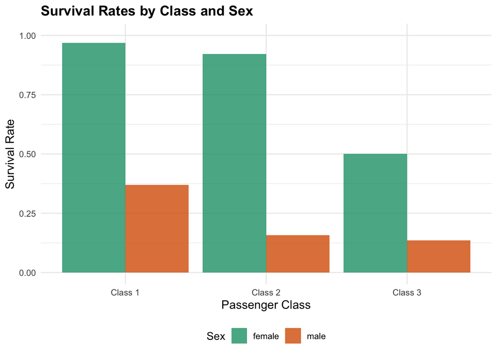

```r
# Create visualization of raw survival rates
survival_by_class_sex <- train %>%
  group_by(Pclass, Sex) %>%
  summarise(
    survival_rate = mean(Survived),
    n = n(),
    .groups = 'drop'
  ) %>%
  mutate(Pclass = paste0("Class ", Pclass))

p_survival <- ggplot(survival_by_class_sex, aes(x = Pclass, y = survival_rate,
                                                 fill = Sex)) +
  geom_col(position = "dodge", alpha = 0.8) +
  theme_minimal() +
  scale_fill_manual(values = c("#1B9E77", "#D95F02")) +
  labs(
    title = "Survival Rates by Class and Sex",
    x = "Passenger Class",
    y = "Survival Rate",
    fill = "Sex"
  ) +
  theme(
    plot.title = element_text(size = 14, face = "bold"),
    axis.title = element_text(size = 12),
    legend.position = "bottom"
  ) +
  ylim(0, 1)

print(p_survival)
```

This visualization establishes the baseline disparities in survival rates across class and sex, providing visual context for the mediation analysis. The stark differences between classes and within classes by sex reveal the magnitude of effects we are attempting to decompose.

### 6.2 Fare Distribution by Class and Survival

[figure not shown]

```r
p_fare <- ggplot(train %>% filter(!is.na(Fare)),
                 aes(x = Pclass, y = Fare, fill = factor(Survived))) +
  geom_boxplot(alpha = 0.7) +
  scale_y_log10() +
  theme_minimal() +
  scale_fill_manual(values = c("#E7298A", "#66A61E"),
                    labels = c("Did Not Survive", "Survived")) +
  labs(
    title = "Fare Distribution by Class and Survival Status",
    x = "Passenger Class",
    y = "Fare (log scale)",
    fill = "Outcome"
  ) +
  theme(
    plot.title = element_text(size = 14, face = "bold"),
    axis.title = element_text(size = 12),
    legend.position = "bottom"
  )

print(p_fare)
```

### 6.3 Family Size Impact

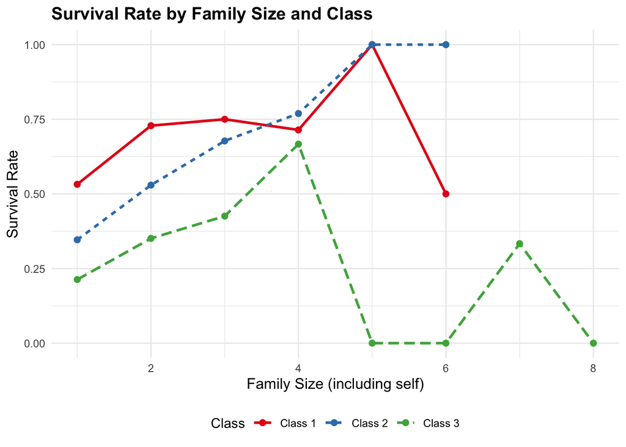

```r
family_viz <- train %>%
  group_by(family_size, Pclass) %>%
  summarise(
    survival_rate = mean(Survived),
    n = n(),
    .groups = 'drop'
  ) %>%
  filter(family_size <= 8) %>%
  mutate(Pclass = paste0("Class ", Pclass))

p_family <- ggplot(family_viz, aes(x = family_size, y = survival_rate,
                                     color = Pclass, linetype = Pclass)) +
  geom_line(size = 1) +
  geom_point(size = 2) +
  theme_minimal() +
  scale_color_manual(values = c("#E41A1C", "#377EB8", "#4DAF4A")) +
  labs(
    title = "Survival Rate by Family Size and Class",
    x = "Family Size (including self)",
    y = "Survival Rate",
    color = "Class",
    linetype = "Class"
  ) +
  theme(
    plot.title = element_text(size = 14, face = "bold"),
    axis.title = element_text(size = 12),
    legend.position = "bottom"
  ) +
  ylim(0, 1)

print(p_family)
```

This visualization shows how family size constrains survival outcomes differently across classes. If larger families experience greater survival challenges uniformly across classes, it suggests family size represents a general constraint rather than a class-specific mechanism.

## 7. Model Diagnostics and Assumptions

### 7.1 Model Fit Assessment

```r
# Compare model fits using AIC
model_fit_comparison <- data.frame(
  Model = c("Model 1: Class Only",
            "Model 3: Class + Fare",
            "Model 4: Class + Family Size",
            "Model 5: Comprehensive"),
  AIC = c(
    AIC(model1),
    AIC(model3),
    AIC(model4),
    AIC(model5)
  ),
  BIC = c(
    BIC(model1),
    BIC(model3),
    BIC(model4),
    BIC(model5)
  )
)

kable(model_fit_comparison, caption = "Model Fit Comparison (AIC and BIC)")
```

Model Fit Comparison (AIC and BIC)

| Model | AIC | BIC |
| --- | --- | --- |
| Model 1: Class Only | 1089.1080 | 1103.4850 |
| Model 3: Class + Fare | 1080.8140 | 1099.9833 |
| Model 4: Class + Family Size | 1089.4419 | 1108.6113 |
| Model 5: Comprehensive | 655.5748 | 737.8507 |

Lower AIC and BIC values indicate better model fit. Comparing these fit statistics helps us assess whether adding mediator variables improves our ability to explain survival beyond the class effect alone. This is essential for evaluating whether our mediation mechanisms are statistically important.

### 7.2 Assumptions and Limitations

The mediation analysis presented here relies on several important assumptions:

1. **No unmeasured confounding**: We assume that no important variables confound the relationships between class, mediators, and survival.
2. **Correct functional form**: We assume logistic regression adequately captures the relationships.
3. **Linearity of mediators**: Relationships between mediators and survival are assumed linear on the logit scale.
4. **Complete information**: We partially address missing data by subsetting to complete cases, but this may introduce bias.
5. **Interpretation of proxies**: Cabin, fare, and family size are imperfect proxies for the constructs we aim to measure (access, constraints).

## 8. Summary and Next Steps

### 8.1 Analysis Summary

This analysis provides a framework for decomposing the class-survival gap into components mediated by access/constraint mechanisms and residual direct class effects. By progressively adding potential mediators to our models, we can quantify how much of the total class effect operates through measured access pathways.

### 8.2 Key Questions Addressed

- **Model 1** answers: What is the total survival advantage of 1st vs. 2nd vs. 3rd class?
- **Models 2-4** answer: How much of this advantage is explained by specific access/constraint mechanisms?
- **Model 5** answers: When all mechanisms are considered together, does class still have a substantial direct effect?

### 8.3 Recommended Next Steps for Extended Analysis

1. **Sensitivity Analysis**: Test alternative specifications of mediator variables
2. **Formal Mediation Testing**: Implement Baron-Kenny approach or newer mediation packages
3. **Subgroup Analysis**: Examine whether mediation pathways differ by sex or age
4. **Interaction Effects**: Test whether access proxies interact with class (e.g., does fare matter differently by class?)
5. **Temporal Dynamics**: If available, incorporate timing information about when evacuation occurred

## 9. Appendix: Data Processing Notes

```r
# Summary of analytical sample construction
analytical_note <- data.frame(
  Sample = c("Full Dataset", "Complete Cabin Data", "Complete Fare Data",
             "Comprehensive Model"),
  N = c(
    nrow(train),
    nrow(train_cabin_subset),
    nrow(train_fare_subset),
    nrow(train_comprehensive)
  )
)

kable(analytical_note, caption = "Analytical Sample Sizes")
```

Analytical Sample Sizes

| Sample | N |
| --- | --- |
| Full Dataset | 891 |
| Complete Cabin Data | 891 |
| Complete Fare Data | 891 |
| Comprehensive Model | 714 |

Different analyses use different subsets of the data based on variable completeness. The comprehensive model uses the smallest sample (those with complete information across all variables), while initial models use larger samples. This trade-off between completeness and sample size is important for interpretation.